# Exercises for Spatial Point Processes

Spatial Epidemiologi Autumn 2021

Alexander, Victor, Mikel

15 desember, 2021

# Task 1

## Data import and cleaning

```r
nucli.23=read.table(file="nucli23.txt",header=T,sep="\t")
head(nucli.23)
```

```
##     NUCLI niu data_pos        X       Y
## 111    23 276       10 300855.2 4494651
## 112    23 294       12 300896.9 4494582
## 113    23 295       12 300871.4 4494621
## 114    23 296       12 300868.3 4494634
## 115    23 623       16 300904.1 4494558
## 116    23 624       16 300902.5 4494569
```

```r
summary(nucli.23)
```

```
##      NUCLI         niu           data_pos           X
##  Min.   :23   Min.   :276.0   Min.   :10.00   Min.   :300845
##  1st Qu.:23   1st Qu.:627.8   1st Qu.:16.00   1st Qu.:300870
##  Median :23   Median :681.5   Median :18.00   Median :300884
##  Mean   :23   Mean   :702.8   Mean   :18.17   Mean   :300881
##  3rd Qu.:23   3rd Qu.:796.2   3rd Qu.:20.00   3rd Qu.:300898
##  Max.   :23   Max.   :965.0   Max.   :22.00   Max.   :300905
##        Y
##  Min.   :4494557
##  1st Qu.:4494580
##  Median :4494599
##  Mean   :4494603
##  3rd Qu.:4494627
##  Max.   :4494651
```

```r
poly.23=read.table(file=paste("poly23.txt"),header=T,sep="\t")
summary(poly.23)
```

```
##        X                Y               NUCLI
##  Min.   :300839   Min.   :4494549   Min.   :23
##  1st Qu.:300860   1st Qu.:4494573   1st Qu.:23
##  Median :300878   Median :4494601   Median :23
##  Mean   :300879   Mean   :4494603   Mean   :23
##  3rd Qu.:300900   3rd Qu.:4494632   3rd Qu.:23
##  Max.   :300915   Max.   :4494657   Max.   :23
```

```r
# Change reference of X and Y (to 0).
min.X=min(nucli.23$X)
min.Y=min(nucli.23$Y)
nucli.23$X=nucli.23$X-min.X
nucli.23$Y=nucli.23$Y-min.Y
summary(nucli.23)
```

```
##      NUCLI         niu           data_pos           X               Y
##  Min.   :23   Min.   :276.0   Min.   :10.00   Min.   : 0.00   Min.   : 0.00
##  1st Qu.:23   1st Qu.:627.8   1st Qu.:16.00   1st Qu.:24.20   1st Qu.:23.77
##  Median :23   Median :681.5   Median :18.00   Median :39.01   Median :42.12
##  Mean   :23   Mean   :702.8   Mean   :18.17   Mean   :35.99   Mean   :46.13
##  3rd Qu.:23   3rd Qu.:796.2   3rd Qu.:20.00   3rd Qu.:52.33   3rd Qu.:70.55
##  Max.   :23   Max.   :965.0   Max.   :22.00   Max.   :59.82   Max.   :94.80
```

```r
poly.23$X=poly.23$X-min.X
poly.23$Y=poly.23$Y-min.Y
summary(poly.23)
```

```
##        X                Y              NUCLI
##  Min.   :-6.403   Min.   : -7.06   Min.   :23
##  1st Qu.:14.813   1st Qu.: 16.42   1st Qu.:23
##  Median :33.033   Median : 44.91   Median :23
##  Mean   :33.511   Mean   : 46.86   Mean   :23
##  3rd Qu.:54.248   3rd Qu.: 75.89   3rd Qu.:23
##  Max.   :69.972   Max.   :100.87   Max.   :23
```

## 1.1) Build a ppp object using the “poly23” data as a window.

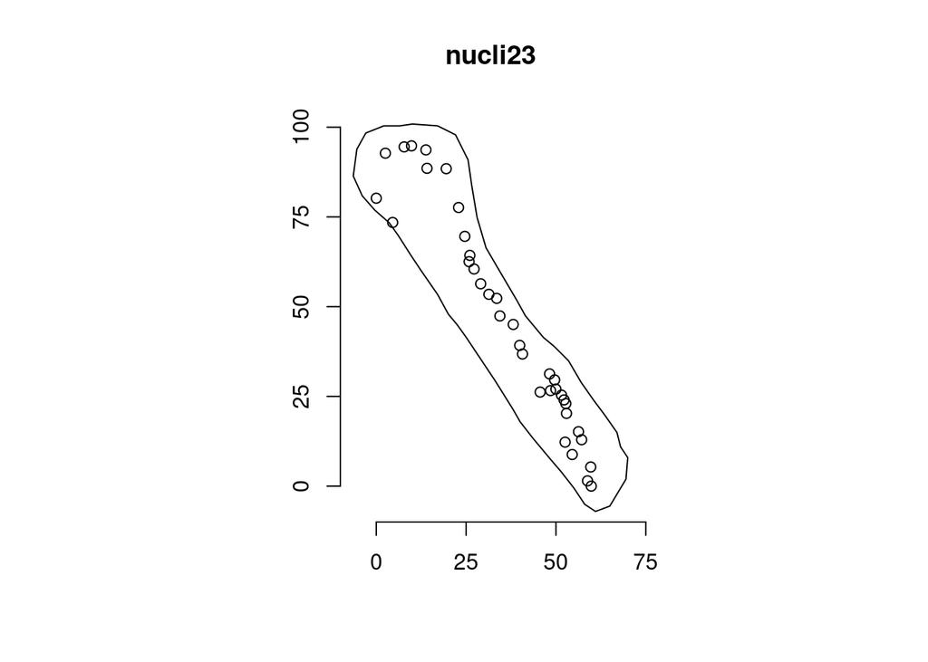

```r
pol.illa<-list(x=poly.23$X,y=poly.23$Y)
n23=ppp(nucli.23$X,nucli.23$Y,poly=pol.illa)
plot(n23,main="nucli23")
axis(1,at=c(seq(0,75,by=25)),pos=c(-10,0))
axis(2,at=c(seq(0,100,by=25)),pos=c(-10,-0))
```

## 1.2) Briefly describe the point pattern process.

```r
summary(n23)
```

```
## Planar point pattern:  36 points
## Average intensity 0.01451131 points per square unit
##
## Coordinates are given to 6 decimal places
##
## Window: polygonal boundary
## single connected closed polygon with 47 vertices
## enclosing rectangle: [-6.40267, 69.97237] x [-7.06032, 100.8694] units
##                      (76.38 x 107.9 units)
## Window area = 2480.82 square units
## Fraction of frame area: 0.301
```

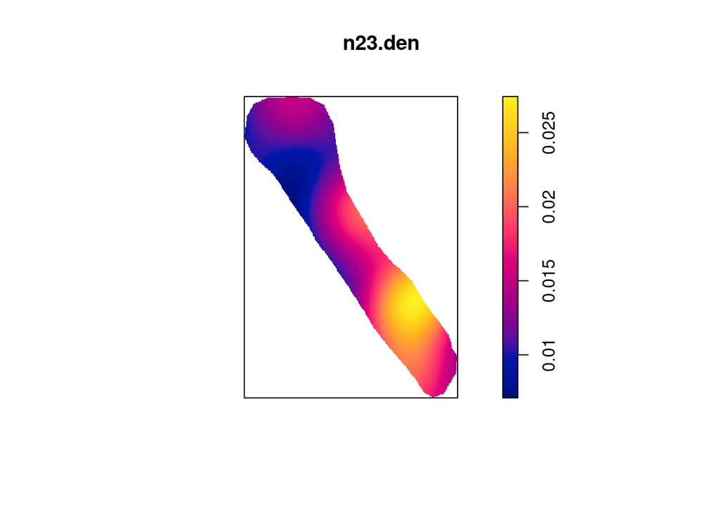

```r
n23.den<-density(n23,dimyx=c(256,256))
plot(n23.den)
```

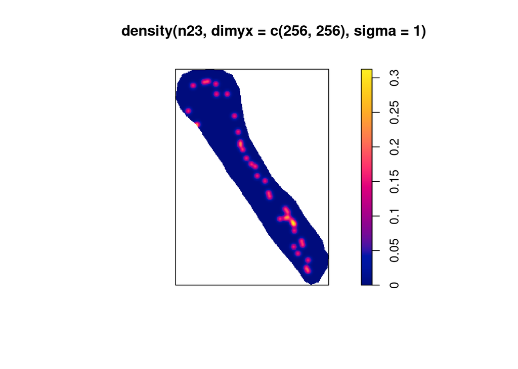

```r
plot(density(n23, dimyx=c(256,256), sigma=1))
```

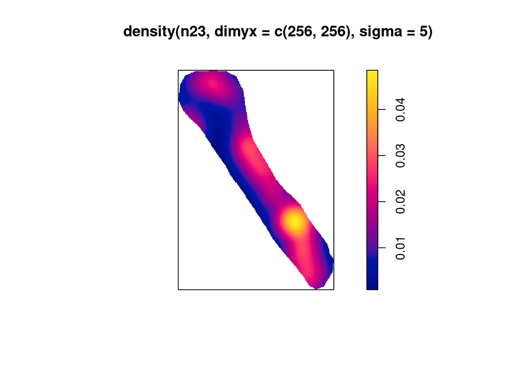

```r
plot(density(n23, dimyx=c(256,256), sigma=5))
```

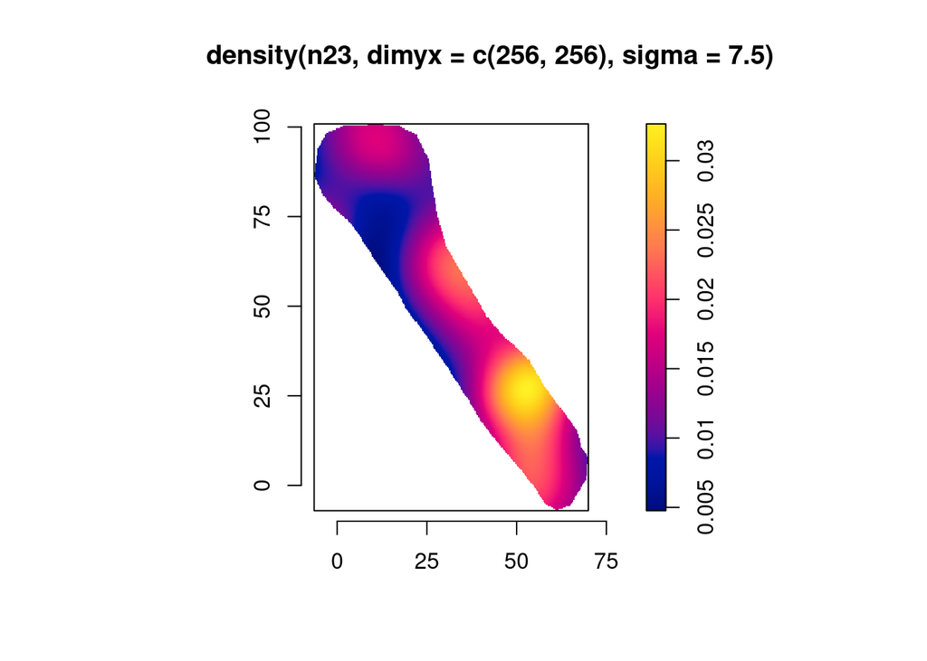

```r
plot(density(n23, dimyx=c(256,256), sigma=7.5))
axis(1,at=c(seq(0,75,by=25)),pos=c(-10,0))
axis(2,at=c(seq(0,100,by=25)),pos=c(-10,-0))
```

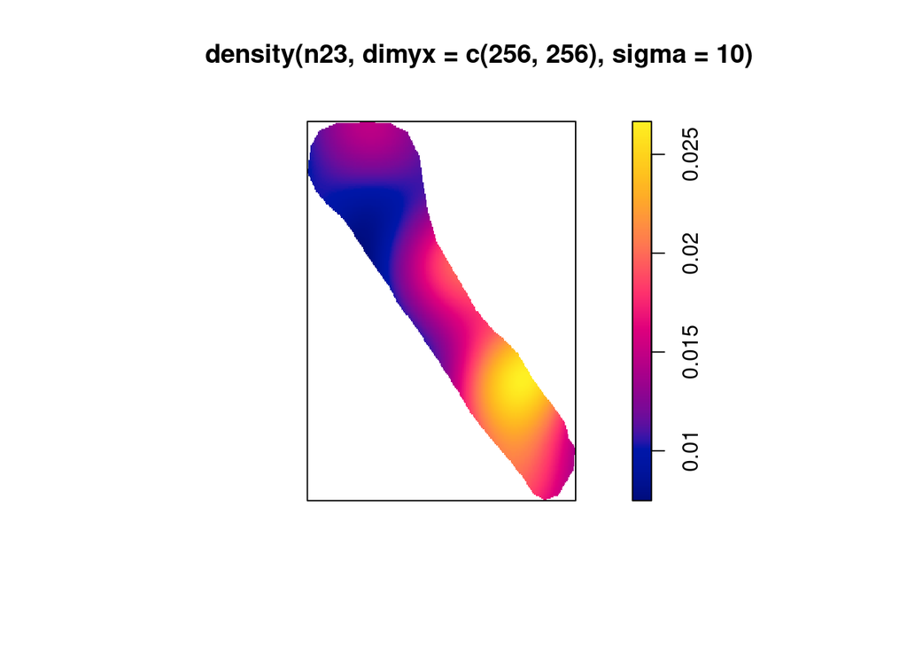

```r
plot(density(n23, dimyx=c(256,256), sigma=10))
```

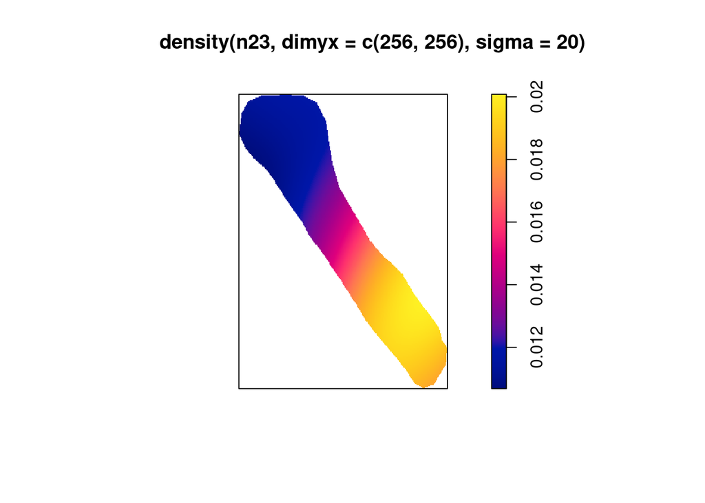

```r
plot(density(n23, dimyx=c(256,256), sigma=20))
```

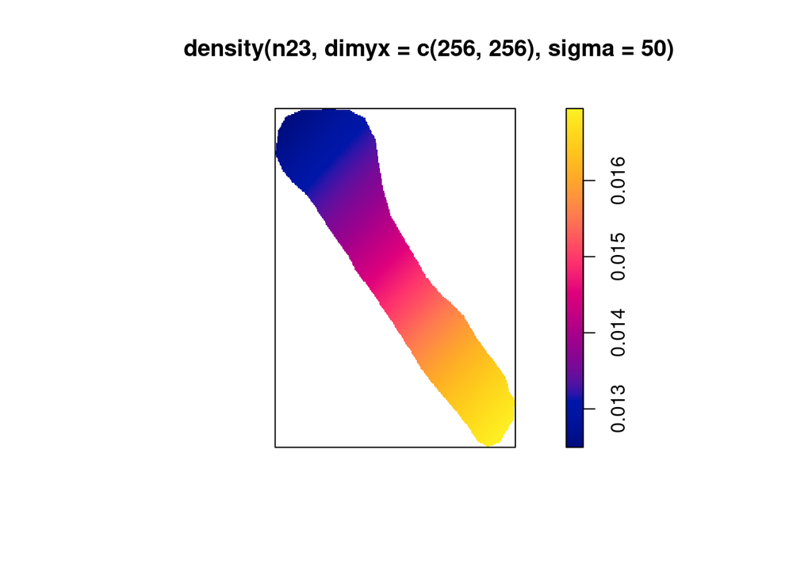

```r
plot(density(n23, dimyx=c(256,256), sigma=50))
```

We can see that sigma = 20 and sigma = 50 gives too much smoothing. Similarly, we can see that sigma = 1 gives to little smoothing. The density with sigma between 5 and 10 looks more informative.

Additionally, we can see that the process is not homogeneous. There are some regions that clearly have a larger intensity of points. The regions around $(x,y) = (60, 25)$ and $(x,y) = (30,60)$ are two examples, where the first one has the largest intensity.

## 1.3) Rebuild the ppp object using the “time to nest” (data_pos variable) as marks.

```r
(n23T=ppp(nucli.23$X,nucli.23$Y,poly=pol.illa,marks=nucli.23$data_pos))
```

```
## Marked planar point pattern: 36 points
## marks are numeric, of storage type  'integer'
## window: polygonal boundary
## enclosing rectangle: [-6.40267, 69.97237] x [-7.06032, 100.8694] units
```

## 1.4) Briefly describe the marked point process.

```r
summary(n23T)
```

```
## Marked planar point pattern:  36 points
## Average intensity 0.01451131 points per square unit
##
## Coordinates are given to 6 decimal places
##
## marks are numeric, of type 'integer'
## Summary:
##    Min. 1st Qu.  Median    Mean 3rd Qu.    Max.
##   10.00   16.00   18.00   18.17   20.00   22.00
##
## Window: polygonal boundary
## single connected closed polygon with 47 vertices
## enclosing rectangle: [-6.40267, 69.97237] x [-7.06032, 100.8694] units
##                      (76.38 x 107.9 units)
## Window area = 2480.82 square units
## Fraction of frame area: 0.301
```

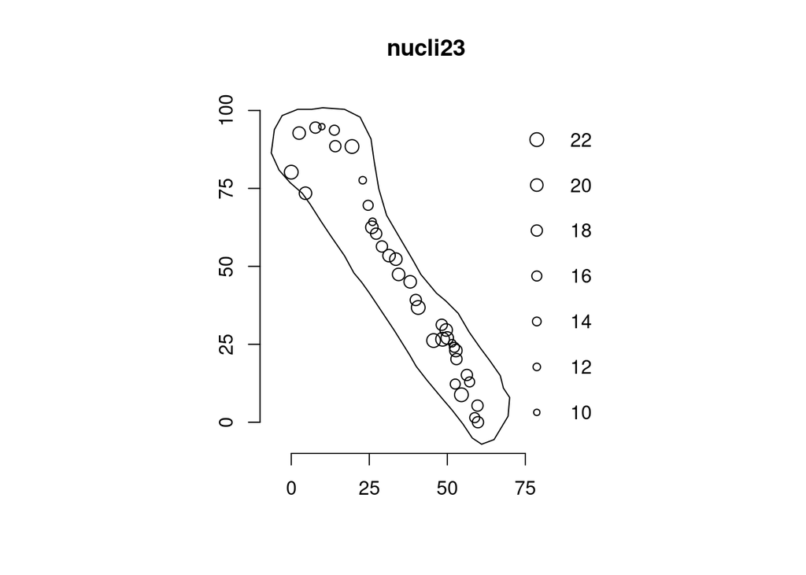

```r
plot(n23T,main="nucli23",markscale=0.2,leg.side="right")
axis(1,at=c(seq(0,75,by=25)),pos=c(-10,0))
axis(2,at=c(seq(0,100,by=25)),pos=c(-10,-0))
```

```r
# Hard to interpret, categorize time into categories for every 4 days instead.

DPOScat=cut(nucli.23$data_pos,breaks=c(9, 12, 14,16, 18, 20, 23),labels=c("10-12","12-14","14-16","16-18", "18-20", "20-22"))
table(DPOScat) # Are no points 12-14. Thus, merge 10-12 and 12-14 into 10-14.
```

```
## DPOScat
## 10-12 12-14 14-16 16-18 18-20 20-22
##     4     0     6    10    10     6
```

```r
DPOScat=cut(nucli.23$data_pos,breaks=c(9, 14,16, 18, 20, 22),labels=c("10-14","14-16","16-18", "18-20", "20-22"))
table(DPOScat) # Are no points 12-14. Thus, merge 10-12 and 12-14 into 10-14.
```

```
## DPOScat
## 10-14 14-16 16-18 18-20 20-22
##     4     6    10    10     6
```

```r
(n23Tcat=ppp(nucli.23$X,nucli.23$Y,poly=pol.illa,marks=DPOScat))
```

```
## Marked planar point pattern: 36 points
## Multitype, with levels = 10-14, 14-16, 16-18, 18-20, 20-22
## window: polygonal boundary
## enclosing rectangle: [-6.40267, 69.97237] x [-7.06032, 100.8694] units
```

```r
summary(n23Tcat)
```

```
## Marked planar point pattern:  36 points
## Average intensity 0.01451131 points per square unit
##
## Coordinates are given to 6 decimal places
##
## Multitype:
##       frequency proportion   intensity
## 10-14         4  0.1111111 0.001612368
## 14-16         6  0.1666667 0.002418552
## 16-18        10  0.2777778 0.004030920
## 18-20        10  0.2777778 0.004030920
## 20-22         6  0.1666667 0.002418552
##
## Window: polygonal boundary
## single connected closed polygon with 47 vertices
## enclosing rectangle: [-6.40267, 69.97237] x [-7.06032, 100.8694] units
##                      (76.38 x 107.9 units)
## Window area = 2480.82 square units
## Fraction of frame area: 0.301
```

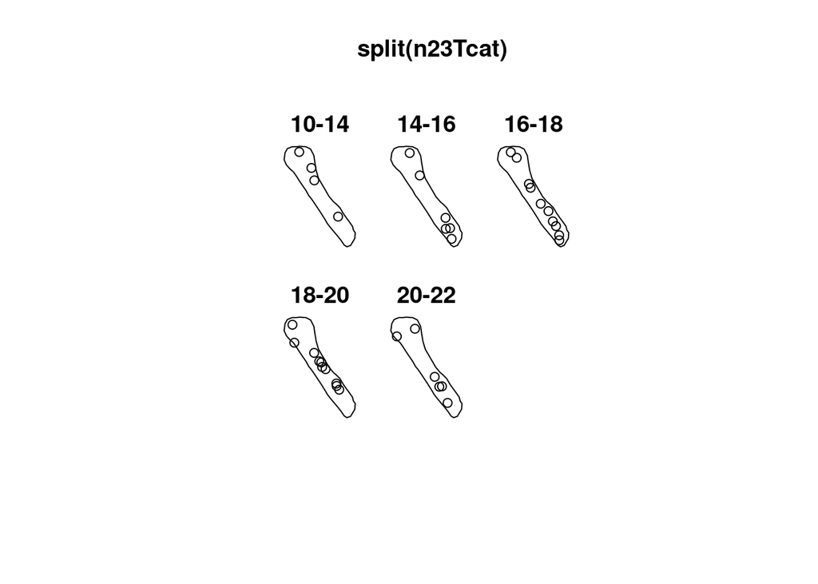

```r
plot(split(n23Tcat))
```

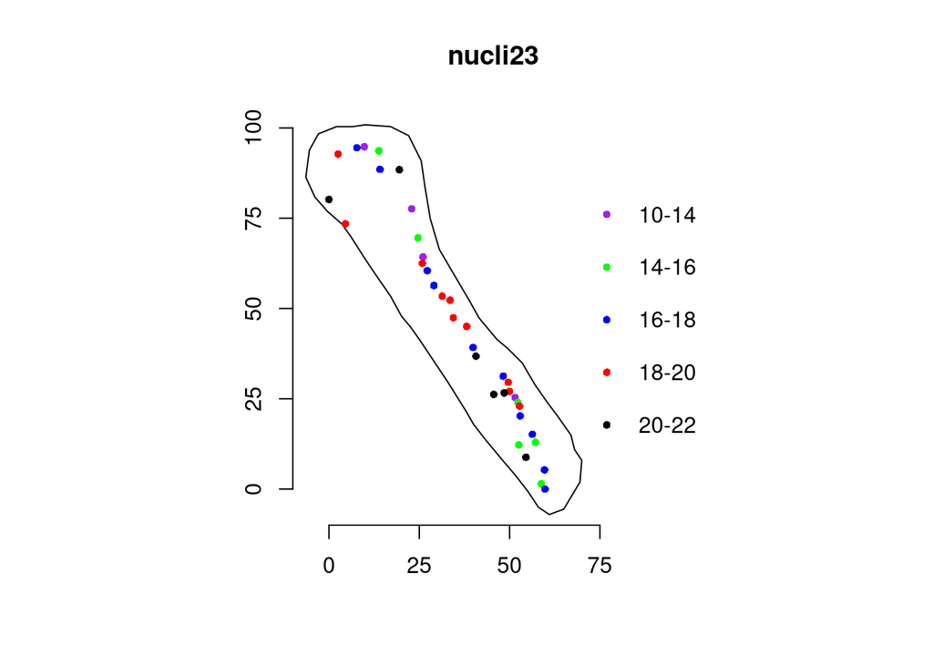

```r
plot(n23Tcat,main="nucli23",cex=0.75,cols=c("purple", "green", "blue","red", "black"),
     chars=rep(16,4),leg.side="right")
axis(1,at=c(seq(0,75,by=25)),pos=c(-10,0))
axis(2,at=c(seq(0,100,by=25)),pos=c(-10,-0))
```

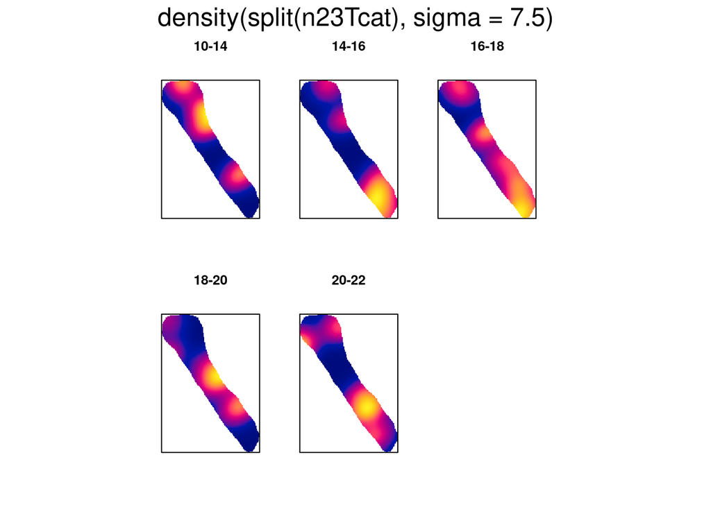

```r
plot(density(split(n23Tcat), sigma = 7.5), ribbon = F)
```

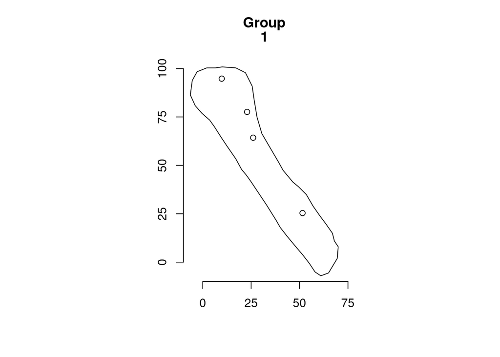

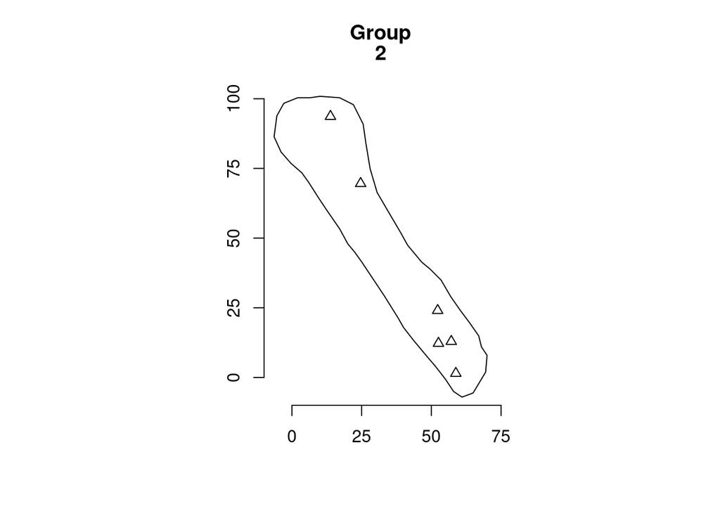

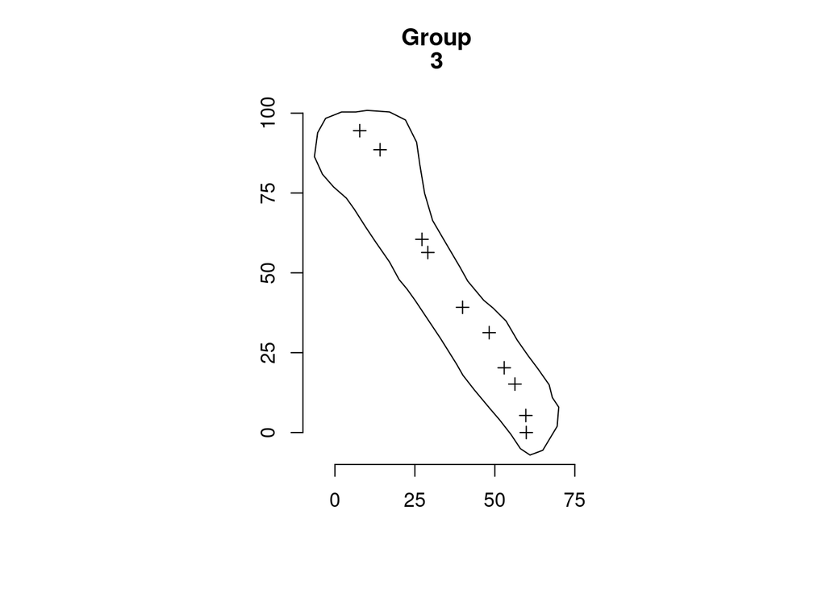

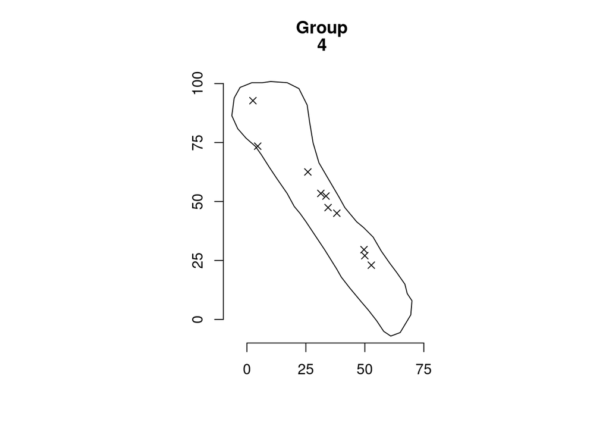

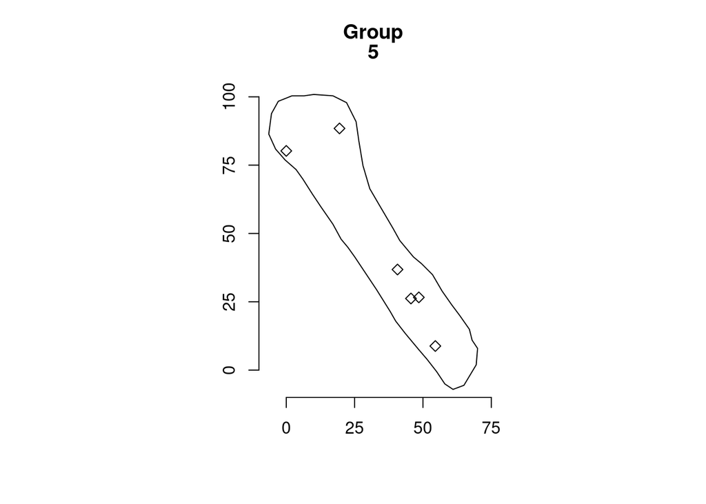

```r
nucli.23.df=data.frame(nucli.23,DPOScat)
n23new=split(nucli.23.df,DPOScat)
for (i in 1:5){
  temp.ppp=ppp(n23new[[i]]$X,n23new[[i]]$Y,poly=pol.illa)
  plot(temp.ppp,pch=i,main=c("Group",i))
  axis(1,at=c(seq(0,75,by=25)),pos=c(-10,0))
  axis(2,at=c(seq(0,100,by=25)),pos=c(-10,-0))
  par(ask=T)
}
```

```r
par(ask=F)
```

It is hard to see a clear pattern in how the point process evolves with time, but we can make some remarks: It looks like the area we noted as high intensity at first ((x,y) = (60, 25)) stays high intensity through all times that were recorded. One can think that it never gets saturated with nests, i.e. it is a good area for nesting, with room,throughout all recorded time. The other area we noted as relatively high intensity ((x,y) = (30,60)) is most “popular” for nesting between weeks 16 and 20. There is also an area around (x,y) = (10,90) (in the north-west) that has some nests in all weeks.

# Task 2

## 2.1) Give a point estimate and a 95% confidence interval of the intensity, assuming a homogeneous Poisson process.

When assuming a homogeneous Poisson process, a point estimate of the intensity is simply the average intensity in the window. This means that the point estimate can be read from the summary of the ppp-object,

```r
summary(n23)
```

```
## Planar point pattern:  36 points
## Average intensity 0.01451131 points per square unit
##
## Coordinates are given to 6 decimal places
##
## Window: polygonal boundary
## single connected closed polygon with 47 vertices
## enclosing rectangle: [-6.40267, 69.97237] x [-7.06032, 100.8694] units
##                      (76.38 x 107.9 units)
## Window area = 2480.82 square units
## Fraction of frame area: 0.301
```

i.e. the point estimation is 0.0145113. The confidence interval can be found from the results shown below **I think!!??**

```r
model1=ppm(n23, ~1)
model1
```

```
## Stationary Poisson process
## Intensity: 0.01451131
##              Estimate      S.E.   CI95.lo   CI95.hi Ztest      Zval
## log(lambda) -4.232827 0.1666667 -4.559487 -3.906166   *** -25.39696
```

## 2.2) Assess the Completely Spatial Randomness hypothesis.

The Completely Spatial Randomness (CSR) hypothesis can be assessed with a chi-squared test based on quadrat counts or a Kolmogorov-Smirnov test. First, let us perform the chi-squared test

```r
# Tried to set own brakes, but did not get it to work properly.
#M <- quadrat.test(n23, xbreaks = c(0, 20, 40, 60), ybreaks = c(20, 40, 60, 80, 100))
M <- quadrat.test(n23, nx = 2, ny = 3)
M
```

```
##
##  Chi-squared test of CSR using quadrat counts
##
## data:  n23
## X2 = 2.8589, df = 3, p-value = 0.8278
## alternative hypothesis: two.sided
##
## Quadrats: 4 tiles (irregular windows)
```

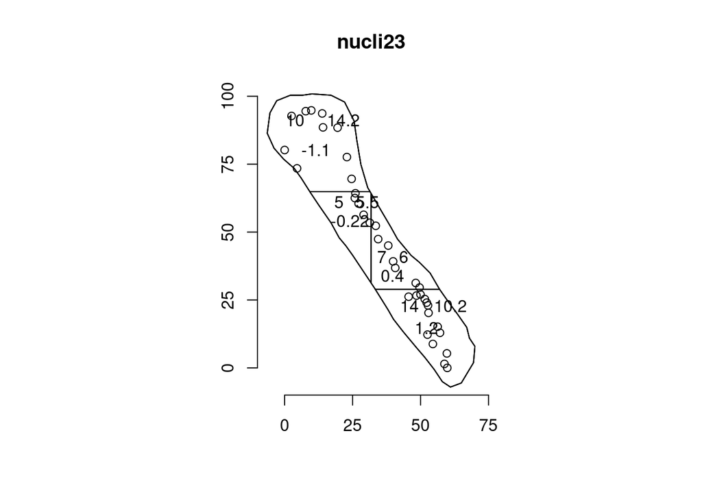

```r
plot(n23,main="nucli23")
plot(M, add = TRUE)
axis(1,at=c(seq(0,75,by=25)),pos=c(-10,0))
axis(2,at=c(seq(0,100,by=25)),pos=c(-10,-0))
```

Since the test above has a very large $p$-value, we cannot conclude that this is a completely random spatial process, since we cannot reject the null hypothesis of CSR. **Not sure if this makes sense right now, think more**

http://rstudio-pubs-static.s3.amazonaws.com/5292_2b2fae3795a144b2a4b486fd2fc6fc57.html

Next, the Kolmogorov-Smirnov test is performed.

```r
KS=cdf.test(n23,covariate="x")
KS
```

```
##
##  Spatial Kolmogorov-Smirnov test of CSR in two dimensions
##
## data:  covariate 'x' evaluated at points of 'n23'
##      and transformed to uniform distribution under CSR
## D = 0.1792, p-value = 0.1751
## alternative hypothesis: two-sided
```

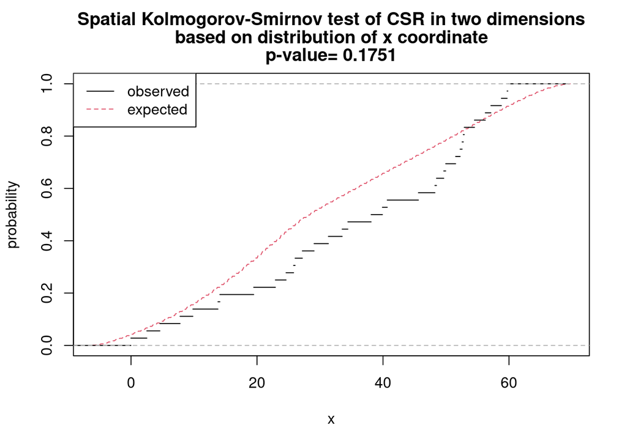

```r
plot(KS)
```

```r
KS=cdf.test(n23,covariate="y")
KS
```

```
##
##  Spatial Kolmogorov-Smirnov test of CSR in two dimensions
##
## data:  covariate 'y' evaluated at points of 'n23'
##      and transformed to uniform distribution under CSR
## D = 0.13456, p-value = 0.4905
## alternative hypothesis: two-sided
```

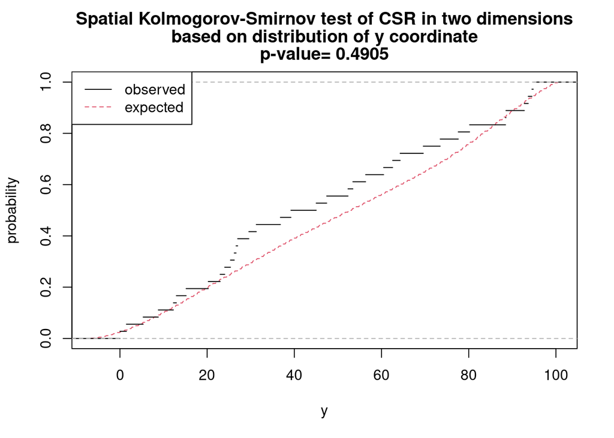

```r
plot(KS)
```

The $p$-values from this test are also quite large, which means that the Kolmogorov-Smirnov test does not give enough evidence against the null hypothesis of CSR.

Thus, both these two tests lead to the same conclusion; we cannot reject the null-hypothesis of CSR, i.e. we have no evidence of this process not being CSR.

## 2.3) Fit an inhomogeneous Poisson model to data.

```r
# fit an homogeneous poisson model
model1=ppm(n23, ~1)
model1
```

```
## Stationary Poisson process
## Intensity: 0.01451131
##              Estimate      S.E.   CI95.lo   CI95.hi Ztest      Zval
## log(lambda) -4.232827 0.1666667 -4.559487 -3.906166   *** -25.39696
```

```r
plot(model1)
```

```
## Nothing plotted -- all plots selected are flat surfaces.
```

```r
# inhomogeneous Poisson model
model2=ppm(n23, ~x + y)
model2
```

```
## Nonstationary Poisson process
##
## Log intensity:  ~x + y
##
## Fitted trend coefficients:
## (Intercept)           x           y
## -6.09288023  0.03457419  0.01440722
##
##                Estimate       S.E.     CI95.lo     CI95.hi Ztest       Zval
## (Intercept) -6.09288023 1.49066696 -9.01453379 -3.17122667   *** -4.0873518
## x            0.03457419 0.02315571 -0.01081017  0.07995855        1.4931170
## y            0.01440722 0.01462969 -0.01426646  0.04308089        0.9847927
```

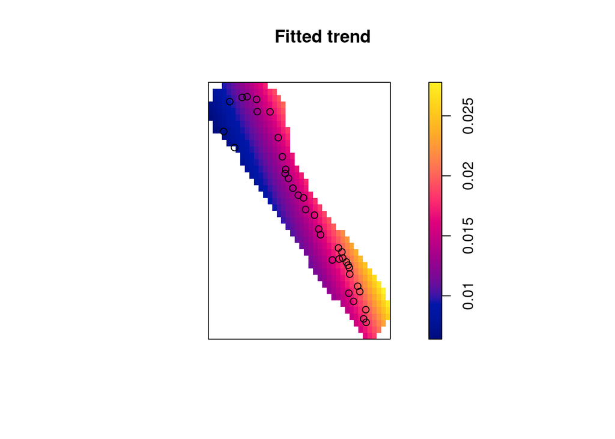

```r
plot(model2, se=F)
```

**Look at some residuals or something as well?**

# Task 3